# Analysis of Thuong et al., 2008

2016-05-27

**Last updated:** 2016-11-14

**Code version:** 32a1e676d90c15b2f56d650dbdc529f3257611ba

```r
library("knitr")
opts_chunk$set(cache = FALSE)
```

http://www.ncbi.nlm.nih.gov/pubmed/19057661

http://journals.plos.org/plospathogens/article?id=10.1371/journal.ppat.1000229#s2

https://www.ncbi.nlm.nih.gov/geo/query/acc.cgi?acc=GSE11199

http://www.bioconductor.org/packages/release/bioc/html/affy.html

http://bioconductor.org/packages/release/bioc/vignettes/GEOquery/inst/doc/GEOquery.html

http://www.bioconductor.org/packages/release/data/annotation/html/hgu133plus2.db.html

## Setup

```r
library("GEOquery")
library("affy")
library("tidyr")
library("limma")
library("biomaRt")
library("dplyr")
library("gplots")
```

## Download processed data

```r
geo_fname <- "../data/GSE11199.rds"
if (!file.exists(geo_fname)) {
  gse <- getGEO(GEO = "GSE11199")
#   class(gse)
#   length(gse)
  gse <- gse[[1]]
  saveRDS(gse, geo_fname)
} else {
  gse <- readRDS(geo_fname)
}
class(gse)
```

```
## [1] "ExpressionSet"
## attr(,"package")
## [1] "Biobase"
```

```r
x <- exprs(gse)
```

## Download and pre-process the raw data

The only information they provided on GEO was “Raw CEL intensity data were RMA normalized using R/Bioconductor”. Thus I just used the recommendation from the affy package example for the other steps.

```r
process_raw_fname <- "../data/thuong2008.rds"
if (file.exists(process_raw_fname)) {
  eset <- readRDS(process_raw_fname)
} else {
  # Download
  getGEOSuppFiles(GEO = "GSE11199")
  untar("GSE11199/GSE11199_RAW.tar", exdir = "GSE11199")
  # Import
  raw <- ReadAffy(filenames = Sys.glob("GSE11199/*CEL.gz"), compress = TRUE)
  # Pre-process
  eset <- expresso(raw,
                   bgcorrect.method = "rma",
                   normalize.method = "quantiles",
                   pmcorrect.method = "pmonly",
                   summary.method = "medianpolish")
  saveRDS(eset, process_raw_fname)
}
```

## The processed data is similar to a standard workflow

Their processed data is very similar to the results of pre-processing the raw data with the recommendations from the affy package, so I’ll use their pre-processed data since that is more convenient.

```r
dim(x)
```

```
## [1] 54675    24
```

```r
y <- exprs(eset)
x[1:5, 1:5]
```

```
##           GSM280331 GSM280332 GSM280333 GSM280334 GSM280335
## 1007_s_at  7.172262  7.319121  7.321613  7.314201  7.139134
## 1053_at    5.251088  5.338482  5.487148  5.567036  5.295166
## 117_at     6.051131  5.922791  5.700554  5.913266  5.442634
## 121_at     8.043315  8.018646  8.074790  7.993529  7.568867
## 1255_g_at  2.971468  2.812389  3.111926  3.125926  2.908381
```

```r
y[1:5, 1:5]
```

```
##           GSM280331.CEL.gz GSM280332.CEL.gz GSM280333.CEL.gz
## 1007_s_at         7.172840         7.319765         7.322188
## 1053_at           5.252651         5.340009         5.488841
## 117_at            6.052171         5.924602         5.702535
## 121_at            8.043858         8.019037         8.075185
## 1255_g_at         2.969890         2.810781         3.110568
##           GSM280334.CEL.gz GSM280335.CEL.gz
## 1007_s_at         7.314940         7.139801
## 1053_at           5.568736         5.296613
## 117_at            5.915228         5.444308
## 121_at            7.993957         7.569440
## 1255_g_at         3.124530         2.906697
```

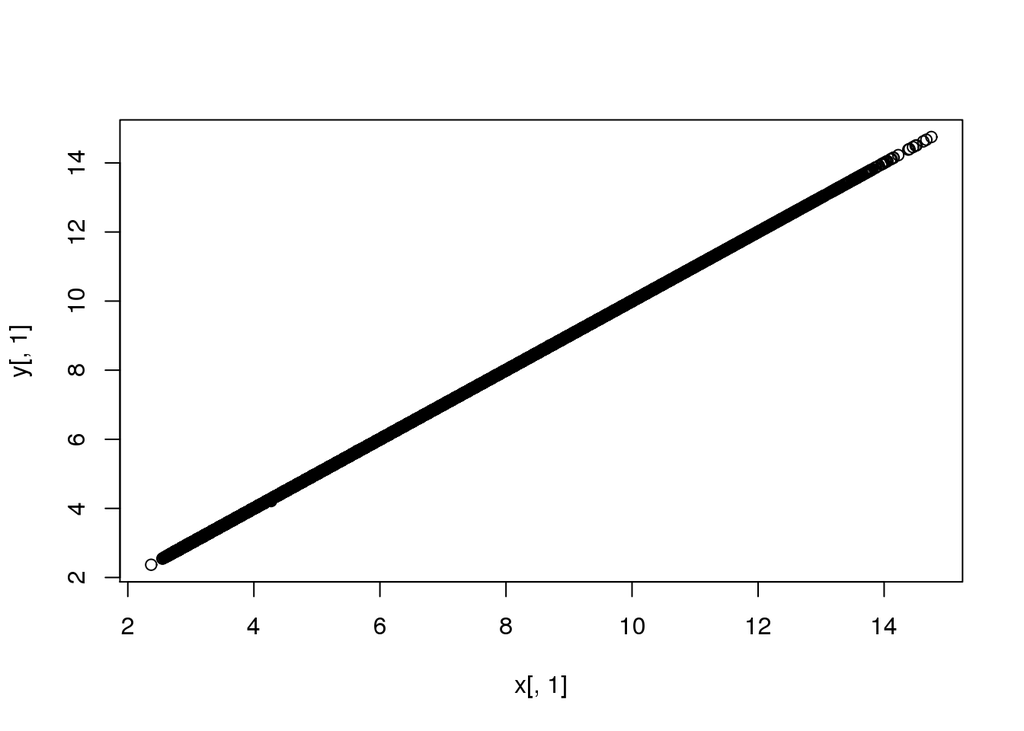

```r
plot(x[, 1], y[, 1])
```

```r
cor(x[, 1], y[, 1])
```

```
## [1] 0.9999999
```

```r
z <- cor(cbind(x, y))
dim(z)
```

```
## [1] 48 48
```

```r
min(z)
```

```
## [1] 0.7764725
```

```r
median(z)
```

```
## [1] 0.9608738
```

## Prepare sample annotation

```r
anno <- pData(gse)[, 1]
anno <- as.data.frame(anno)
anno <- separate(anno, col = anno, into = c("individual", "treatment"))
anno$treatment <- factor(anno$treatment, levels = c("unstim", "stim"),
                         labels = c("none", "infected"))
anno$status <- substr(anno$individual, 1, 1)
anno$status <- factor(anno$status, levels = c("L", "P", "T"),
                      labels = c("latent", "pulmonary", "meningeal"))
colnames(x) <- paste(anno$individual, anno$treatment, sep = ".")
table(anno$treatment, anno$status)
```

```
##
##            latent pulmonary meningeal
##   none          4         4         4
##   infected      4         4         4
```

## limma analysis (probe-level)

Following limma manual sections 9.3, 9.5.2, and 9.7.

```r
f <- paste(anno$status, anno$treatment, sep = ".")
f <- factor(f)
design <- model.matrix(~0 + f)
colnames(design) <- levels(f)
colSums(design)
```

```
##    latent.infected        latent.none meningeal.infected
##                  4                  4                  4
##     meningeal.none pulmonary.infected     pulmonary.none
##                  4                  4                  4
```

```r
corfit <- duplicateCorrelation(x, design, block = anno$individual)
corfit$consensus
```

```
## [1] 0.1740633
```

```r
fit <- lmFit(x, design, block = anno$individual, correlation = corfit$consensus)
contrast_matrix <- makeContrasts(
  latent = latent.infected - latent.none,
  pulmonary = pulmonary.infected - pulmonary.none,
  # meningeal = meningeal.infected - meningeal.none,
  interaction = (pulmonary.infected - pulmonary.none) -
                (latent.infected - latent.none),
  levels = design)
fit2 <- contrasts.fit(fit, contrast_matrix)
fit2 <- eBayes(fit2)
results <- decideTests(fit2)
summary(results)
```

```
##    latent pulmonary interaction
## -1   3456       112           8
## 0   47777     53968       54666
## 1    3442       595           1
```

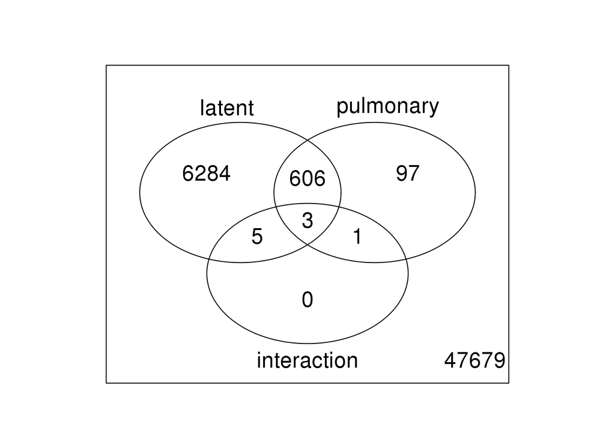

```r
vennDiagram(results)
```

## Mapping probes to genes

Download probe annotation.

```r
ensembl <- useMart(host = "dec2015.archive.ensembl.org",
                   biomart = "ENSEMBL_MART_ENSEMBL",
                   dataset = "hsapiens_gene_ensembl")
probe2id <- getBM(attributes = c("affy_hg_u133_plus_2", "ensembl_gene_id",
                                 "chromosome_name", "status",
                                 "external_gene_name", "gene_biotype"),
                   filters = "affy_hg_u133_plus_2",
                   values = as.character(fData(gse)$ID),
                   mart = ensembl)
head(probe2id)
```

```
##   affy_hg_u133_plus_2 ensembl_gene_id chromosome_name status
## 1        1553551_s_at ENSG00000198888              MT  KNOWN
## 2        1553551_s_at ENSG00000210100              MT  KNOWN
## 3        1553551_s_at ENSG00000210112              MT  KNOWN
## 4        1553551_s_at ENSG00000198763              MT  KNOWN
## 5          1553569_at ENSG00000198804              MT  KNOWN
## 6        1553538_s_at ENSG00000198804              MT  KNOWN
##   external_gene_name   gene_biotype
## 1             MT-ND1 protein_coding
## 2              MT-TI        Mt_tRNA
## 3              MT-TM        Mt_tRNA
## 4             MT-ND2 protein_coding
## 5             MT-CO1 protein_coding
## 6             MT-CO1 protein_coding
```

Filtering by chromosome and biotype.

```r
probes <- probe2id[probe2id$chromosome_name %in% c(1:22, "X", "Y", "MT") &
                   probe2id$gene_biotype == "protein_coding", ]
nrow(probes)
```

```
## [1] 37934
```

```r
length(unique(probes$affy_hg_u133_plus_2))
```

```
## [1] 36022
```

Keeping only those probes that unambiguously tag one protein-coding gene.

```r
genes_per_probe <- table(probes$affy_hg_u133_plus_2)
ambiguous_probes <- names(genes_per_probe)[genes_per_probe > 1]
good_probes <- names(genes_per_probe)[genes_per_probe == 1]
probes_1pergene <- probes[probes$affy_hg_u133_plus_2 %in% good_probes, ]
stopifnot(length(probes_1pergene$affy_hg_u133_plus_2) ==
          length(unique(probes_1pergene$affy_hg_u133_plus_2)))
probes_per_gene <- table(probes_1pergene$ensembl_gene_id)
table(probes_per_gene)
```

```
## probes_per_gene
##    1    2    3    4    5    6    7    8    9   10   11   13   14   15
## 7597 4781 2543 1180  544  228   83   35   15    7    1    1    1    1
```

Many genes are tagged by more than one probe. I’ll average them to get one value per gene.

```r
x_filtered <- x[probes_1pergene$affy_hg_u133_plus_2, ]
x_filtered <- as.data.frame(x_filtered)
x_filtered$ensembl <- probes_1pergene$ensembl_gene_id
x_mean <- x_filtered %>%
  group_by(ensembl) %>%
  summarise_each(funs(mean)) %>%
  as.data.frame
stopifnot(length(x_mean$ensembl) == length(unique(x_mean$ensembl)))
rownames(x_mean) <- x_mean$ensembl
x_mean <- x_mean %>% select(-ensembl)
```

## limma analysis (gene-level)

Following limma manual sections 9.3, 9.5.2, and 9.7.

```r
# design matrix defined above in probe-level analysis
colSums(design)
```

```
##    latent.infected        latent.none meningeal.infected
##                  4                  4                  4
##     meningeal.none pulmonary.infected     pulmonary.none
##                  4                  4                  4
```

```r
corfit_gene <- duplicateCorrelation(x_mean, design, block = anno$individual)
corfit_gene$consensus
```

```
## [1] 0.2050172
```

```r
fit_gene <- lmFit(x_mean, design, block = anno$individual,
                  correlation = corfit_gene$consensus)
# contrast matrix defined above in probe-level analysis
contrast_matrix
```

```
##                     Contrasts
## Levels               latent pulmonary interaction
##   latent.infected         1         0          -1
##   latent.none            -1         0           1
##   meningeal.infected      0         0           0
##   meningeal.none          0         0           0
##   pulmonary.infected      0         1           1
##   pulmonary.none          0        -1          -1
```

```r
fit2_gene <- contrasts.fit(fit_gene, contrast_matrix)
fit2_gene <- eBayes(fit2_gene)
results_gene <- decideTests(fit2_gene)
summary(results_gene)
```

```
##    latent pulmonary interaction
## -1   1318       115           0
## 0   13864     16500       17017
## 1    1835       402           0
```

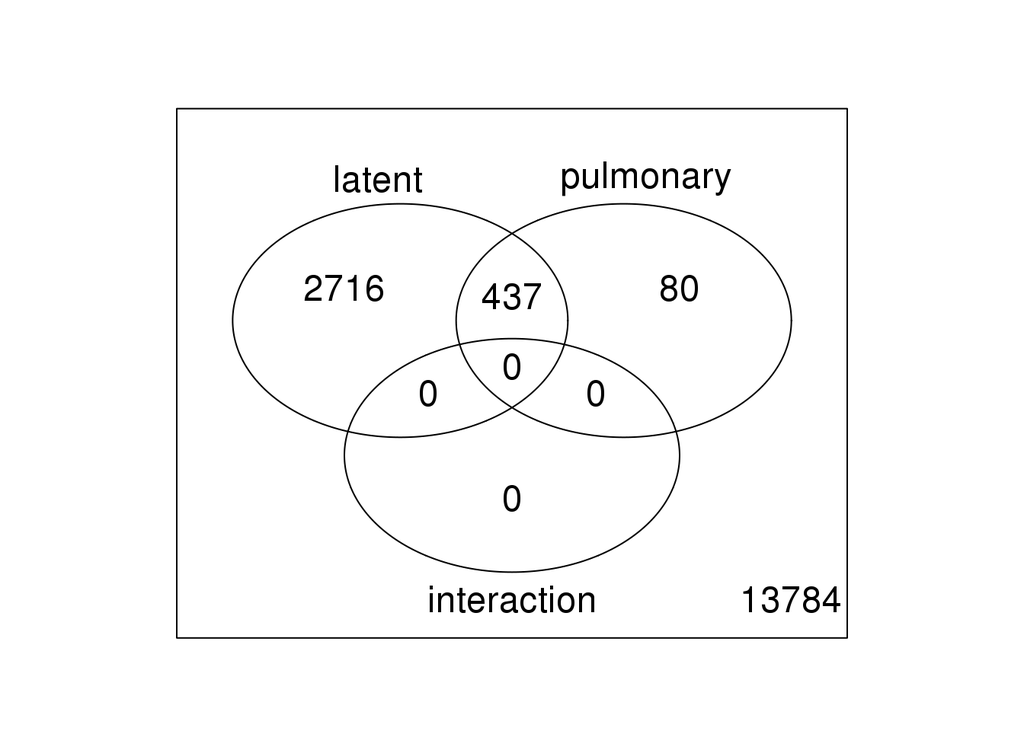

```r
vennDiagram(results_gene)
```

## Exploration

Perform PCA

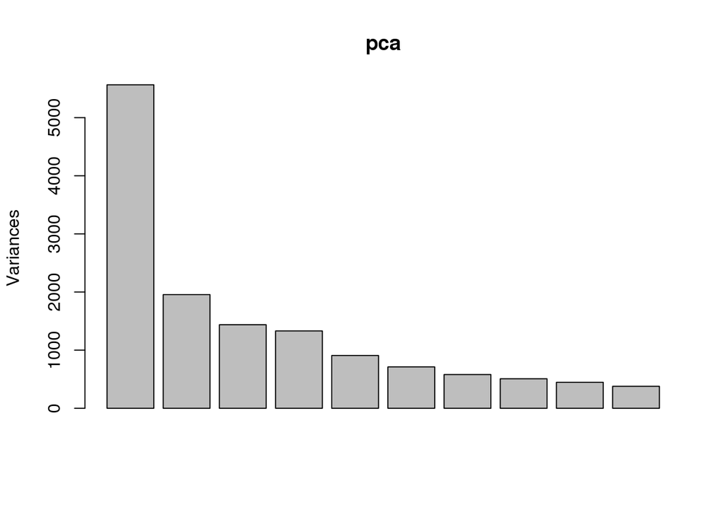

```r
pca <- prcomp(t(x_mean), retx = TRUE, center = TRUE, scale. = TRUE)
plot(pca)
```

PC1 is driven by the outlier LTB2. PC2 is the treatment effect.

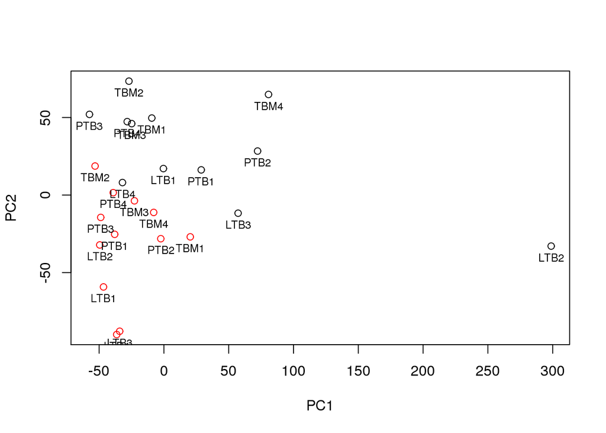

```r
plot(pca$x[, "PC1"], pca$x[, "PC2"], col = anno$treatment,
     xlab = "PC1", ylab = "PC2")
text(pca$x[, "PC1"], pca$x[, "PC2"], labels = anno$individual,
     pos = 1, cex = 0.75)
```

Maybe PC3 is starting to get at susceptibility status?

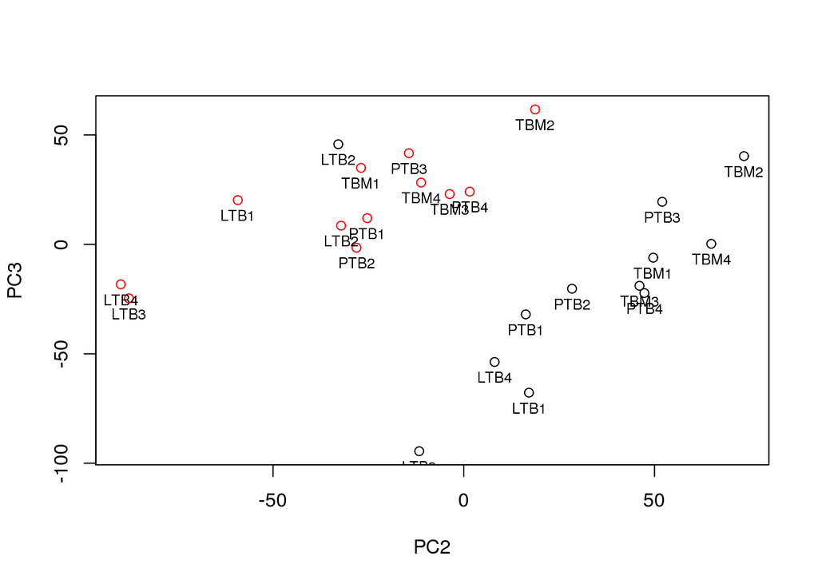

```r
plot(pca$x[, "PC2"], pca$x[, "PC3"], col = anno$treatment,
     xlab = "PC2", ylab = "PC3")
text(pca$x[, "PC2"], pca$x[, "PC3"], labels = anno$individual,
     pos = 1, cex = 0.75)
```

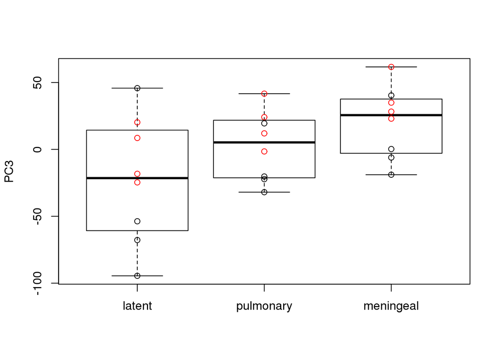

```r
boxplot(pca$x[, "PC3"] ~ anno$status, ylab = "PC3")
points(pca$x[, "PC3"] ~ anno$status, col = anno$treatment)
```

How does hierarchical clustering sort the outlier?

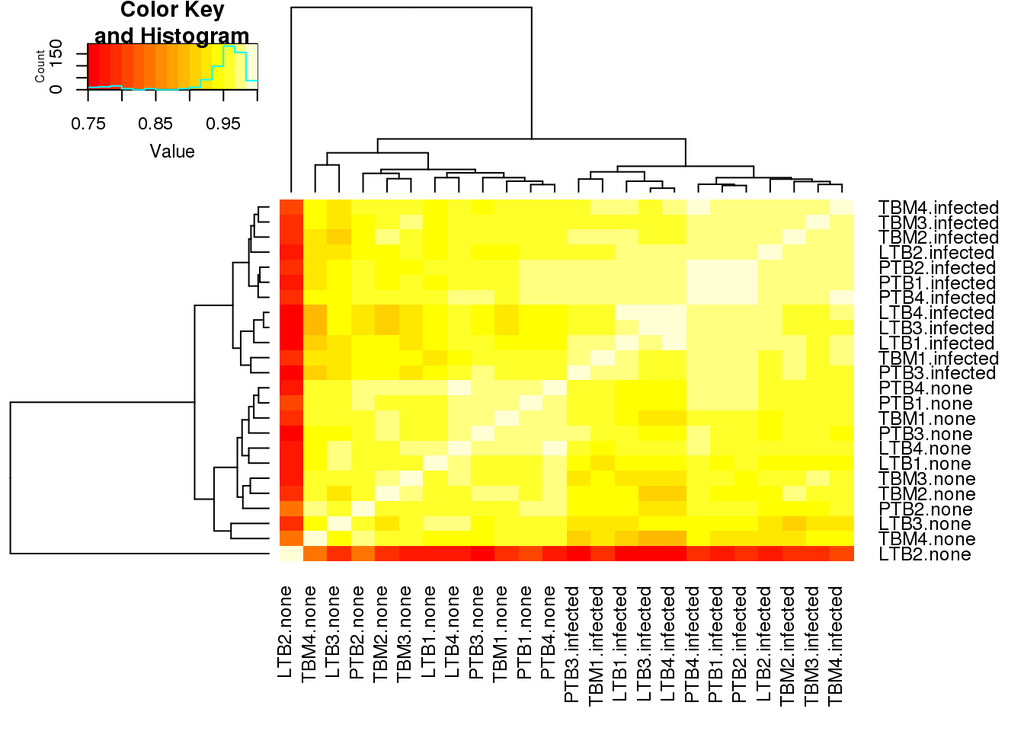

```r
heatmap.2(cor(x_mean), trace = "none", margins = c(7, 7))
```

LTB2.none does not cluster with either the infected or non-infected samples. They also note in their paper that LTB2 is an outlier, however they only visualize the fold change (Fig. S1).

How different is this sample? Looking at the top 2000 most variable genes.

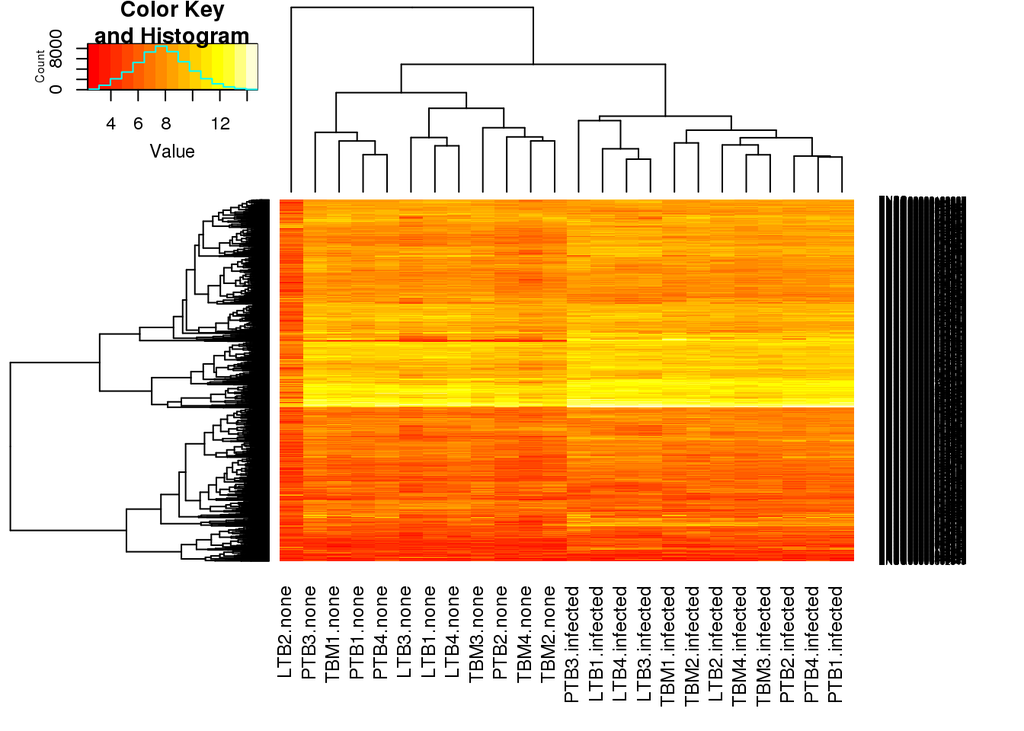

```r
select_var <- function(x, y) {x[order(apply(x, 1, var), decreasing = TRUE), ][1:y, ]}
x_mean_sub <- select_var(x_mean, 2000)
heatmap.2(as.matrix(x_mean_sub), trace = "none", margins = c(7, 7))
```

I think LTB2.none needs to be excluded entirely.